# Model biulding for predicting barbell lift manners

Xiaozhuo Wang

2017-09-18

## Background

Using devices such as Jawbone Up, Nike FuelBand, and Fitbit it is now possible to collect a large amount of data about personal activity relatively inexpensively. These type of devices are part of the quantified self movement - a group of enthusiasts who take measurements about themselves regularly to improve their health, to find patterns in their behavior, or because they are tech geeks. One thing that people regularly do is quantify how much of a particular activity they do, but they rarely quantify how well they do it. In this project, we will use data from accelerometers on the belt, forearm, arm, and dumbell of 6 participants, who were asked to perform barbell lifts correctly and incorrectly in 5 different ways. The goal of our project is to predict the manner in which they did the exercise. More information and the data for this project come from this source: http://web.archive.org/web/20161224072740/http:/groupware.les.inf.puc-rio.br/har

## Data preparation

The training data for this project are available [here](https://d396qusza40orc.cloudfront.net/predmachlearn/pml-training.csv), the test data are available [here](https://d396qusza40orc.cloudfront.net/predmachlearn/pml-testing.csv).

When exploring the data with `summary` function, it can be found that there are plenty of colums filled with NAs or blanks, such variables are excluded. Some colums like row numbers, user names and time stamps are also excluded considering the goal of this project. The `classe` variable (the manner in which they did the exercise) is the outcome, and the remained 52 variables will be used as predictors.

The `pml_training` data are sliced into 70% for training and 30% for validing.

The dimensions of the data sets are listed:

```
##          Observation Variable
## Training       13737       53
## Validing        5885       53
## Testing           20       53
```

## Model biulding

In this project, three training methods are performed and compared to choose the best one: random forest (rf), boosting with trees (gbm) and quadratic discriminant analysis (qda). `rf` and `gbm` are chosen because of their high accuracy, `qda` is chosen because of reduced computational complexity (assumes multivariate Gaussian distribution with different covariance for predictor variables).

The `rf` model used train control with a 10-fold cross validation method to avoid over-fitting. Other parameters in model training are all by default of `train` function of `caret` package.

The time consuming for training models is listed below. `rf` model has the highest computational complexity, costs over 200 times and twice the training time for `qda` and `gbm` medels.

```
##     Time for training
## rf               1457 s
## gbm               634 s
## qda                 7 s
```

## Model validing

```
##                       Accuracy Error
## mod_rf :in sample        1.000 0.000
##         out of sample    0.994 0.006
## mod_gbm:in sample        0.974 0.026
##         out of sample    0.965 0.035
## mod_qda:in sample        0.899 0.101
##         out of sample    0.900 0.100
```

The accuracy of predicted validing data are used for estimating out of sample error. As the above table shows, the `rf` model has the overall highest accuracy (both in sample and out of sample) among the three models. It can be seen that out of sample error is higher than in sample error of rf model, but still less than 0.01. The `gbm` model has the medium accuracy and the `qda` model has the lowest accuracy.

The distribution plot of possible number of right answers predicted by the three models are created below:

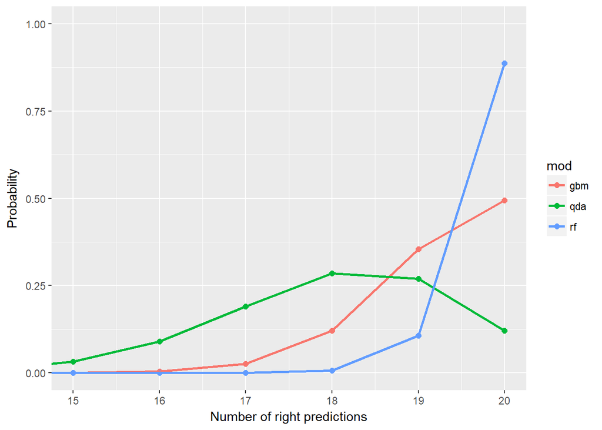

It’s easy to find that the `rf` model has the highest probability of getting all-right prediction (0.888). Thus we chose it as our final model for predicting the testing data.

## Predicting results

The predicted classes are:

```
##  [1] B A B A A E D B A A B C B A E E A B B B
## Levels: A B C D E
```

The predictions of the `rf` model get 20 right out of 20 observations in testing data, which means an excellent 100% accuracy.

The accuracy of `gbm` and `qda` models are also tested, in this case, they are 20/20 and 19/20, respectively.

*The source code for this project can be reviewed [here](https://github.com/catree1988/practicalmachinelearning).*